# Statistical Inference Peer Reviewed Project

Nirmal Ghimire

10/3/2020

## Overview:

This is a class project for Statistical Inference Course in Data Science Certification Program through John Hopkins University. This project conducts thousands of simulations of data of exponential distribution in R and assess how their means and variance compare with the theoretical ones. The second half of the project analyzes the ToothGrowth data and performs some basic exploratory analyses.

## Part 1-Simulation Exercise

This project investigates the exponential distribution in R and compares it with the Central Limit Theorem. The exponential distribution was simulated in R using ‘rexp (n, lambda)’. If you are not sure, exponential distribution has a mean and standard deviation of 1 over lambda (1/ʎ). Lambda was set to (0.2) for all the simulations. This project investigates the distribution of averages of 40 exponentials using a thousand of simulations. This project attempted to answer following questions: 1. Does the sample mean vary from the theoretical mean? 2. Calculate the sample variance and compare it with the theoretical variance of the distribution. 3. Check if the distribution is approximately normal. The answer to question 3 should focus on the difference between the distribution of a large collection of random exponentials and the distribution of a large collection of averages of 40 exponentials.

#### setting seed for generating data

```r
set.seed(-123)
```

#### setting up 40 exponential

```r
n<-40
```

#### setting lambda to 0.2 for all simulations

```r
lambda<- 0.2
```

#### Need 1000 simulations

```r
S<-1000
```

#### setting z value for 95% confidence interval (CI)

```r
z<-1.96
```

## A. Simulating data in R and calculating means

#### Creating dataframe with 40 columns and 1000 exponential simulations

```r
mydata<-matrix(rexp(n*S,lambda),nrow=S)
```

#### Checking if the data frame is created

```r
str(mydata)
```

```
##  num [1:1000, 1:40] 3.28 6.62 1.43 2.97 14.94 ...
```

# B. Calculating Sample Mean and Theoretical Mean Using Simulated Data

#### Mean of simulated data per row

```r
Row_Mean<-rowMeans(mydata)
```

#### Checking if that works

```r
summary(Row_Mean)
```

```
##    Min. 1st Qu.  Median    Mean 3rd Qu.    Max.
##   2.872   4.439   4.967   5.019   5.500   8.183
```

#### Single mean of all row means

```r
MeanOfMean<-mean(Row_Mean)
```

#### Printing the Simulated Mean

```r
MeanOfMean
```

```
## [1] 5.018855
```

#### Calculating Theoretical Mean

```r
theoreticalMean<-1/lambda
```

#### Printing the Theoretical Mean

```r
theoreticalMean
```

```
## [1] 5
```

## C. Calculating Sample Variance and Theoretical Variance Using Simulated Data

```r
sampleVar<-var(Row_Mean)
```

#### printing the sample variance

```r
sampleVar
```

```
## [1] 0.7073296
```

#### Calculating the theoretical variance

```r
theoreticalVar<-(1/lambda)^2/(n)
```

#### Printing the theoretical variance

```r
theoreticalVar
```

```
## [1] 0.625
```

## D. Checking Data Distribution and Assessing if they are Approximately Normal

#### Histogram of the sample mean

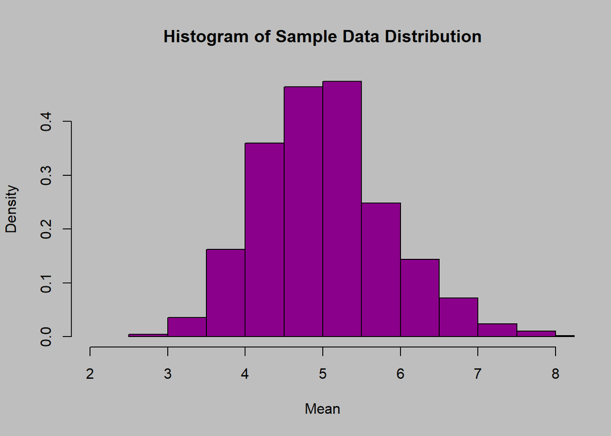

```r
par(bg='grey')
hist(Row_Mean,
     main="Histogram of Sample Data Distribution",
     xlab="Mean",
     xlim=c(2,8),
     col="darkmagenta",
     freq=FALSE
     )
```

## Part 2-Basic Inferential Statistics

This second portion of the project analyzes the ToothGrowth data in the R dataset package and performs the following activities:

#### Invoking Required Libraries

```r
library(ggplot2)
library(dplyr)
```

#### Loading Required Datafile

```r
data(ToothGrowth)
```

## 1. Basic Exploratory Data Analyses

#### a. Quick Checking of Given Dataset

```r
head(ToothGrowth)
```

```
##    len supp dose
## 1  4.2   VC  0.5
## 2 11.5   VC  0.5
## 3  7.3   VC  0.5
## 4  5.8   VC  0.5
## 5  6.4   VC  0.5
## 6 10.0   VC  0.5
```

#### b. Checking the structure of the dataset

```r
str(ToothGrowth)
```

```
## 'data.frame':    60 obs. of  3 variables:
##  $ len : num  4.2 11.5 7.3 5.8 6.4 10 11.2 11.2 5.2 7 ...
##  $ supp: Factor w/ 2 levels "OJ","VC": 2 2 2 2 2 2 2 2 2 2 ...
##  $ dose: num  0.5 0.5 0.5 0.5 0.5 0.5 0.5 0.5 0.5 0.5 ...
```

#### c. Summary of the Dataset

```r
summary(ToothGrowth)
```

```
##       len        supp         dose
##  Min.   : 4.20   OJ:30   Min.   :0.500
##  1st Qu.:13.07   VC:30   1st Qu.:0.500
##  Median :19.25           Median :1.000
##  Mean   :18.81           Mean   :1.167
##  3rd Qu.:25.27           3rd Qu.:2.000
##  Max.   :33.90           Max.   :2.000
```

## 2. Changing dose as a factor

```r
ToothGrowth$dose<-as.factor(ToothGrowth$dose)
```

##### i. Checking if that worked

```r
head(ToothGrowth$dose)
```

```
## [1] 0.5 0.5 0.5 0.5 0.5 0.5
## Levels: 0.5 1 2
```

#### ii. Verifying the mean of the **len** variable by **supplment types**

```r
SupMean=split(ToothGrowth$len,ToothGrowth$supp)
sapply(SupMean,mean)
```

```
##       OJ       VC
## 20.66333 16.96333
```

#### iv. Creating box plot of OJ and VC

```r
e<-ggplot(aes(x=supp,y=len),data=ToothGrowth)
```

#### Experimenting the violin plot and Including Boxplot within

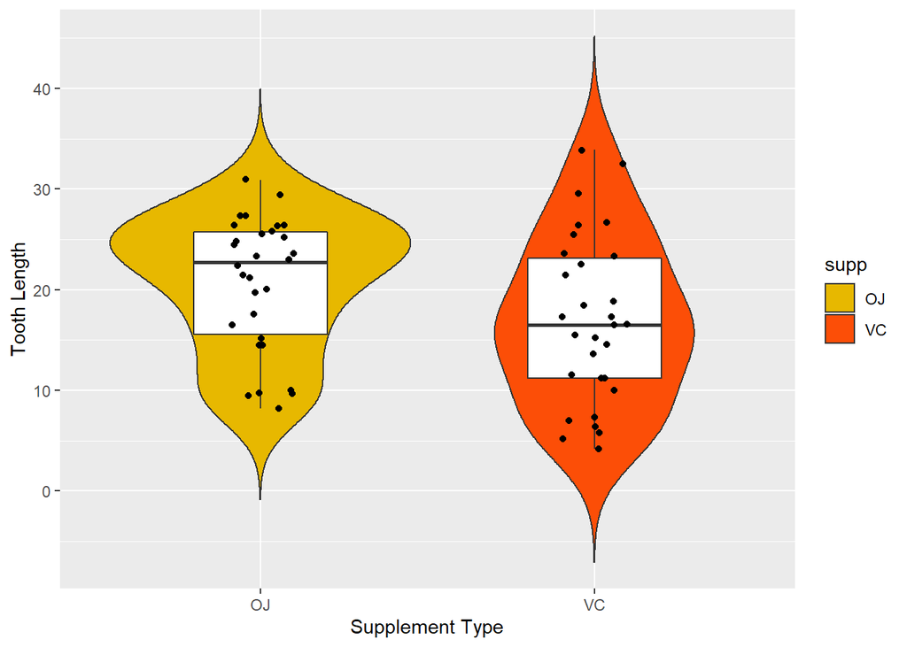

```r
e+geom_violin(aes(fill=supp),trim=FALSE)+
  geom_boxplot(width=0.4)+scale_fill_manual(values=c("#E7B800", "#FC4E07"))+ geom_jitter(width = 0.1)+xlab("Supplement Type")+
  ylab("Tooth Length")
```

### Checking the impact of Vitamin C on tooth length

```r
Mean_dose=split(ToothGrowth$len,ToothGrowth$dose)
sapply(Mean_dose,mean)
```

```
##    0.5      1      2
## 10.605 19.735 26.100
```

### Plotting the findings

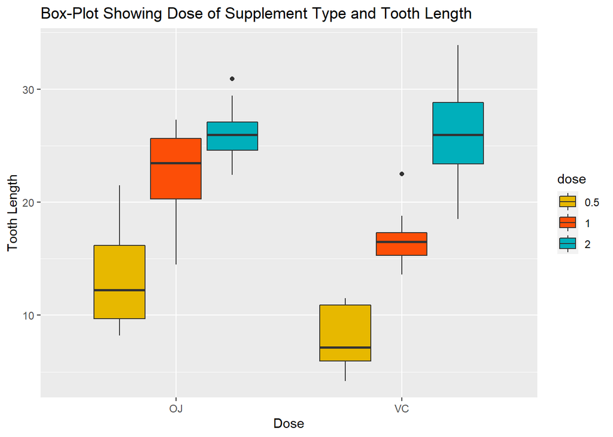

```r
e+ggtitle("Box-Plot Showing Dose of Supplement Type and Tooth Length")+
  geom_boxplot(aes(fill=dose))+scale_fill_manual(values=c("#E7B800",
              "#FC4E07","#00AFBB"))+xlab("Dose")+ylab("Tooth Length")
```

### Tooth Length and Delivery Method

```r
ToothGrowth %>%
  group_by(supp,dose) %>%
  summarise(Q25th_len=quantile(len,0.25),
            Q50th_len=quantile(len,0.5),
            Q75th_len=quantile(len,0.75),
            average_lenth=mean(len),
            SD_len=sd(len))->newtable
newtable
```

```
## # A tibble: 6 x 7
## # Groups:   supp [2]
##   supp  dose  Q25th_len Q50th_len Q75th_len average_lenth SD_len
##   <fct> <fct>     <dbl>     <dbl>     <dbl>         <dbl>  <dbl>
## 1 OJ    0.5        9.7      12.2       16.2         13.2    4.46
## 2 OJ    1         20.3      23.5       25.6         22.7    3.91
## 3 OJ    2         24.6      26.0       27.1         26.1    2.66
## 4 VC    0.5        5.95      7.15      10.9          7.98   2.75
## 5 VC    1         15.3      16.5       17.3         16.8    2.52
## 6 VC    2         23.4      26.0       28.8         26.1    4.80
```

### Calculating ttest to study the relationship between tooth length, supplement type, and dose

```r
test=list()
dose=c(0.5,1,2)
for(m in dose){
  Moj=ToothGrowth$len[ToothGrowth$dose==m & ToothGrowth$supp=="OJ"]
  Mvc=ToothGrowth$len[ToothGrowth$dose==m & ToothGrowth$supp=="VC"]
  t<-t.test(Moj,Mvc)
  id<-paste0("OJ","-","VC",",",m)
  test<-rbind(test,list(id=id,p.value=t$p.value,CI.LOW=t$conf.int[1],
                          CI.HIGH=t$conf.int[2]))
}
test
```

```
##      id          p.value     CI.LOW   CI.HIGH
## [1,] "OJ-VC,0.5" 0.006358607 1.719057 8.780943
## [2,] "OJ-VC,1"   0.001038376 2.802148 9.057852
## [3,] "OJ-VC,2"   0.9638516   -3.79807 3.63807
```